# Tarea 1 Inferencia Estadística

Hairo Ulises Miranda Belmonte

28 de agosto de 2018

5. Para el siguiente ejercicio es necesario el programa R.
1. Escriba un programa en R que reproduzca las gráficas de las funciones de distribución acumulada y de masa de la distribución uniforme que aparecen en las notas del curso. Las gráficas deben verse similares a las figuras de la Figura 1.

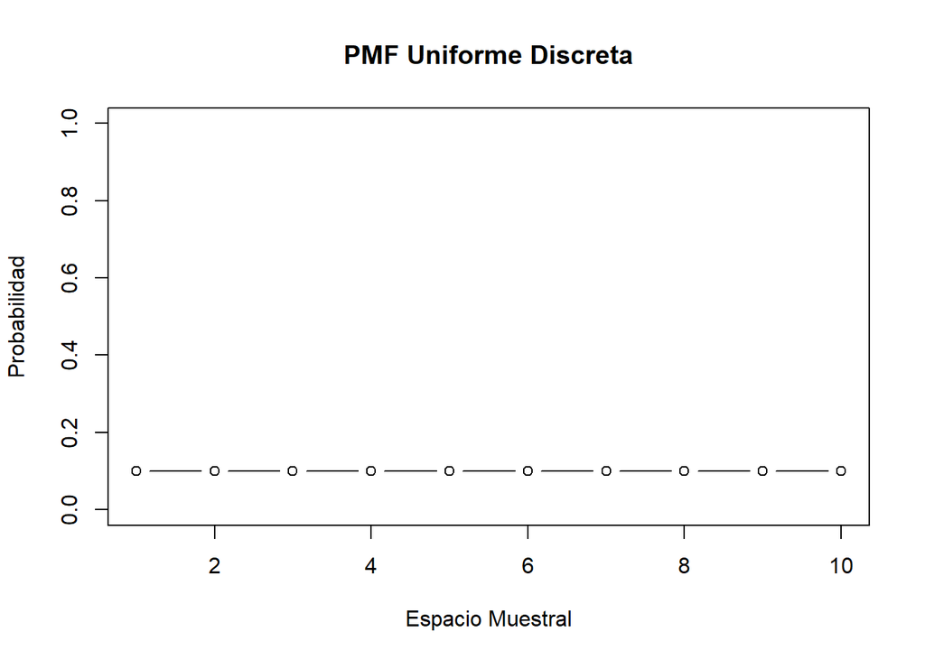

```r
rm(list=ls())
pmf<-0
for(i in seq(1,10,1)){ #generando los lanzamientos
  pmf[i]<-dunif(i,min = 0,max = 10, log = FALSE)
}
SampleSpace<-1:10
plot(SampleSpace,pmf, type = "b", main="PMF Uniforme Discreta", xlab = "Espacio Muestral",
     ylab = "Probabilidad",ylim=c(0, 1))
```

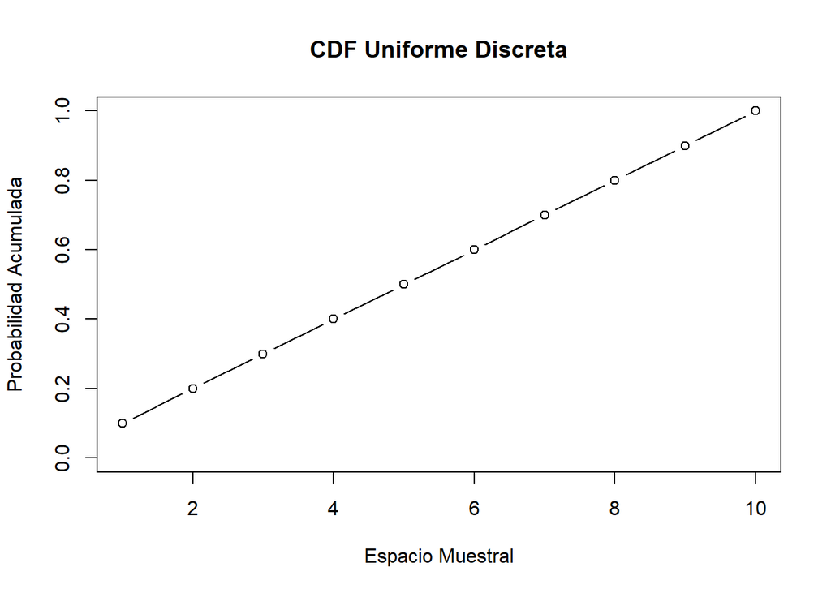

```r
cdf<-0
for(i in seq(1,10,1)){#función de distribución
  cdf[i]<-punif(i,min = 0,max = 10, log = FALSE)
}
SampleSpace<-1:10
plot(SampleSpace,cdf, type = "b", main="CDF Uniforme Discreta", xlab = "Espacio Muestral",
     ylab = "Probabilidad Acumulada",ylim=c(0, 1))
```

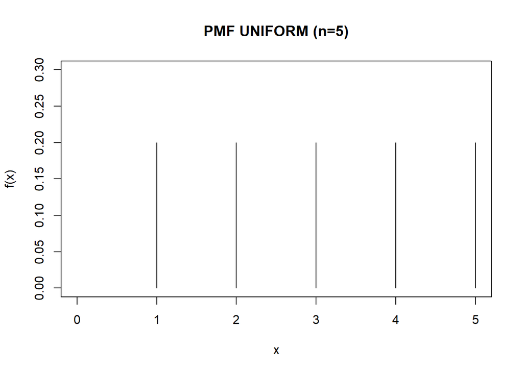

```r
# Diapositiva número 14.
plot(dunif(0:5, 0, 5), type="h", ylim=c(0,.3), xlim=c(0,5), main="PMF UNIFORM (n=5)", ylab="f(x)", xlab="x") # n = 5 pmf
```

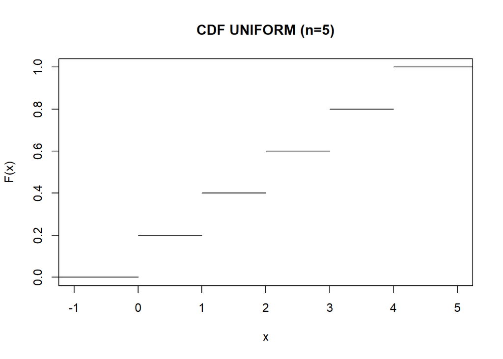

```r
  t <- c(0:4)
x <- punif(0:5, 0, 5) # CDF n=5
plot(stepfun(t, x), xlab="x", ylab="F(x)", main="CDF UNIFORM (n=5)",
     do.points = FALSE, pch = 16,verticals = FALSE)
```

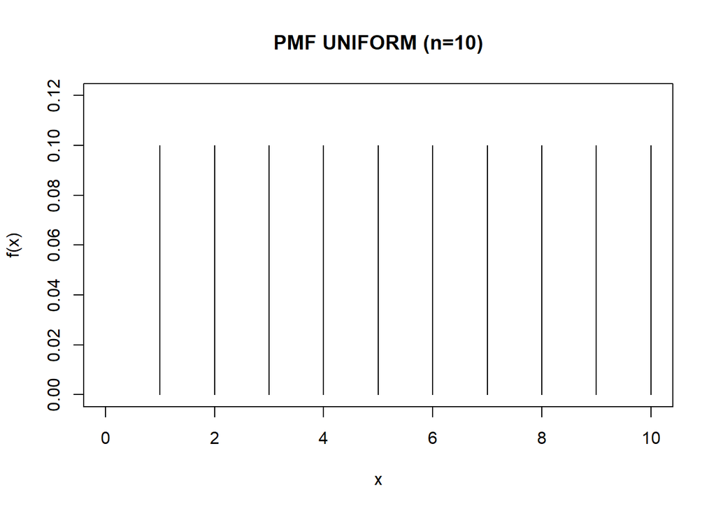

```r
# Diapositiva número 15.
plot(dunif(0:10, 0, 10), type="h", ylim=c(0,.12), xlim=c(0,10), main="PMF UNIFORM (n=10)", ylab="f(x)", xlab="x") # n = 10 pmf
```

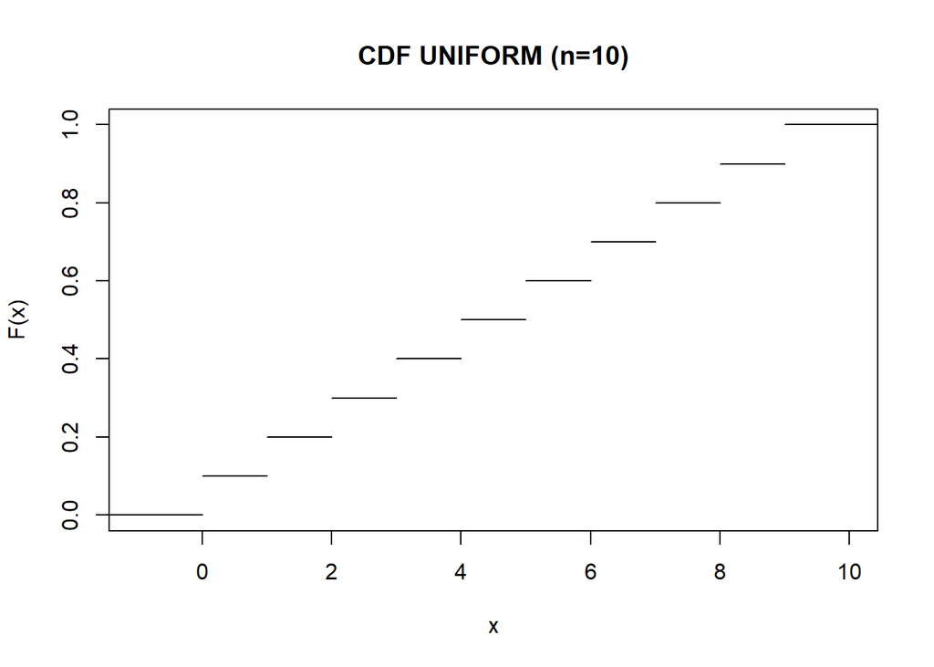

```r
t <- c(0:9)
x <- punif(0:10, 0, 10) # CDF n=10
plot(stepfun(t, x), xlab="x", ylab="F(x)", main="CDF UNIFORM (n=10)",
     do.points = FALSE, pch = 16,verticals = FALSE)
```

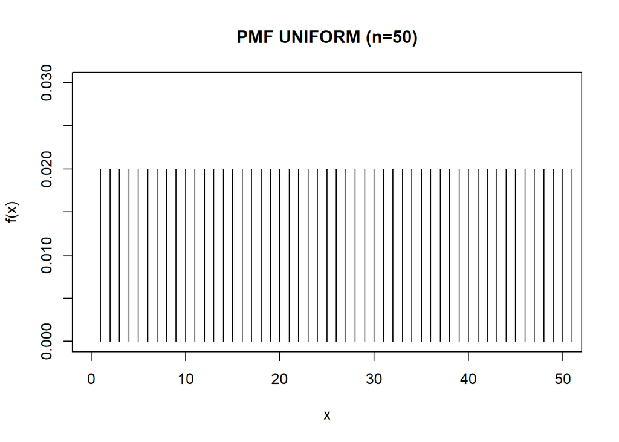

```r
# Diapositiva número 16.
plot(dunif(0:50, 0, 50), type="h", ylim=c(0,.030), xlim=c(0,50), main="PMF UNIFORM (n=50)", ylab="f(x)", xlab="x") # n = 50 pmf
```

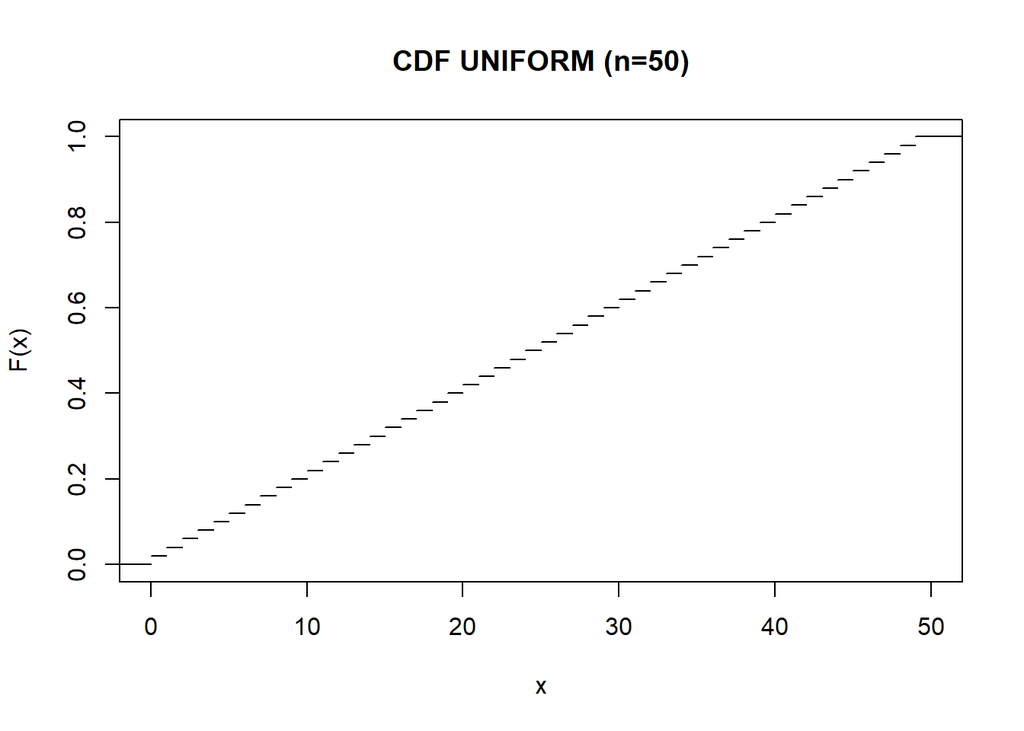

```r
t <- c(0:49)
x <- punif(0:50, 0, 50) # CDF n=50
plot(stepfun(t, x), xlab="x", ylab="F(x)", main="CDF UNIFORM (n=50)",
     do.points = FALSE, pch = 16,verticals = FALSE, xlim=c(0,50))
```

2. Lea en la documentaciónde R, o en cualquier otra fuente de informacion confiable, la explicacion de la funcion sample(x, size, replace=FALSE, prob=NULL). (No es necesario entregar algo para este ejercicio).
3. Usando la funcion sample simule una muestra de tamaño 10000 de la distribucion U(1,…..,10). Fijando la semilla en 13 (set.seed(13)), muestre los resultados de la simulacion en una tabla de frecuencia y calcule la media y la varianza. Sugerencia: Use la funcion table.

```r
rm(list=ls())
set.seed(13)#fijando la semilla en 13
uniform<-sample(round(runif(10000,1,10)))
table(uniform)#frecuencia
```

```
## uniform
##    1    2    3    4    5    6    7    8    9   10
##  585 1073 1104 1093 1156 1089 1102 1043 1200  555
```

```r
#La media es de:
mean(uniform)
```

```
## [1] 5.5137
```

```r
#La varianza es de:
var(uniform)
```

```
## [1] 6.985311
```

4. Grafique las frecuencias de la simulacion anterior.

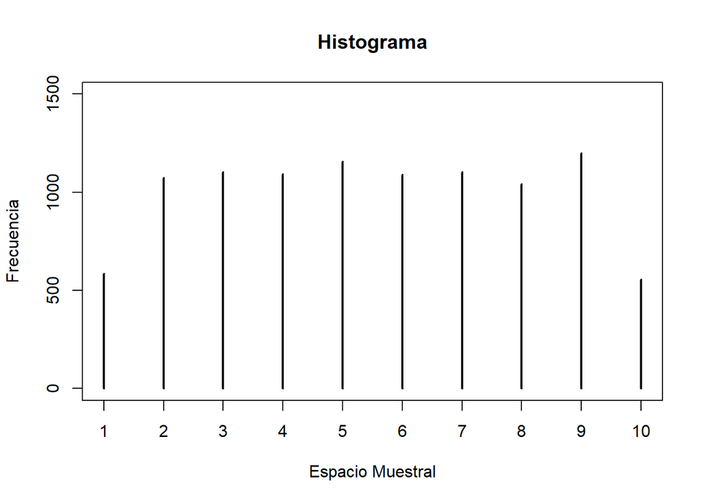

```r
plot(table(uniform), type="h", main="Histograma", xlab = "Espacio Muestral",
     ylab = "Frecuencia", ylim=c(0, 1500))
```

6. Para el siguiente ejercicio también es necesario R.
1. Usando la funciónn sample, simule 10 lanzamientos de una moneda equilibrada y cuente el número de aguilas que obtiene. Repita este proceso 10^6 veces y muestre sus primeros 3 resultados. Grafique las frecuencias del numero de aguilas obtenidas en los 10^6 experiementos. Tambien graque las proporciones (probabilidades) del numero de aguilas obtenidas.
2. Usando la funcion dbinom grafique la funcion de masa de una distribucion B(10; 0:5) sobre la grafica de las proporciones que hizo en el inciso anterior. Que observa?

```r
rm(list=ls())
count3<-0
set.seed(10)#fijando la semilla en 10
LanzamientoMoneda3<-sample(0:1,10,.5)#guardando los lanzamientos
```

Se realizan diez lanzamientos de una moneda con probabilidad de 0.5 porceinto, en el cual, el 0 representa sello y el uno aguila.

```r
LanzamientoMoneda3#resultados de los lanzamientos
```

```
##  [1] 1 0 0 1 0 0 0 0 1 0
```

El numero de aguilas que se obtiene es de:

```r
count3<-(length(which(LanzamientoMoneda3==1)))
count3
```

```
## [1] 3
```

A continuación se repite el proceso 10 a la 6 veces con el comando sample y se saca su función de densidad. Una vez eso, se compara con la función de densidad que proporciona el comando “dbnom” generando una pmf de una binomial.

```r
rm(list=ls())
count4<-rep(0,1000000)
pb<-txtProgressBar(1, 1000000,1)
for (i in seq(1,1000000,1)){
  LanzamientoMoneda4<-sample(0:1,10,.5)
  count4[i]<-(length(which(LanzamientoMoneda4==1)))
  setTxtProgressBar(pb,i)
}
```

Se imprimen los primeros tres resultados

```r
count4[1:3]
```

```
## [1] 4 6 7
```

Se gráfica el número de aguilas que se presentaron en los lanzamientos.

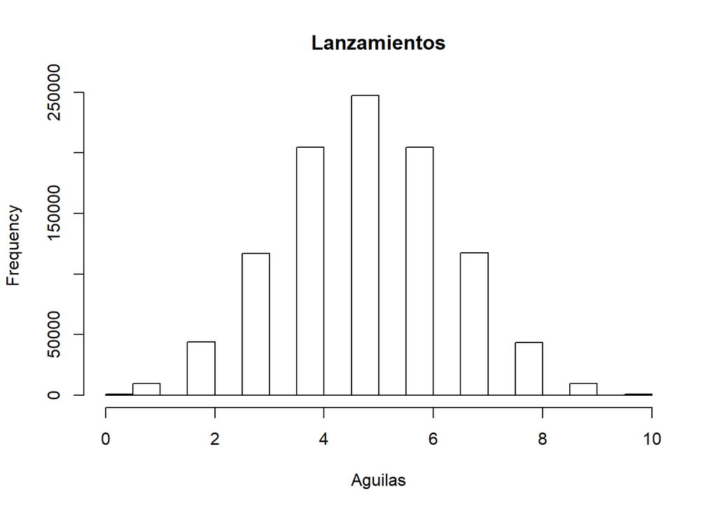

```r
hist(count4, xlab="Aguilas", main="Lanzamientos")
```

Calculamos las probabilidades y realizamos un plot a la función de densidad

```r
b<-table(count4)
c<-rep(0,11)
for (i in seq(1,length(b),1)){
  c[i]<-b[[i]]/1000000
}
```

Se gráfica la distribución de densidad (pmf) de una binomial y se empalma junto la simulación de la densidad anterior.

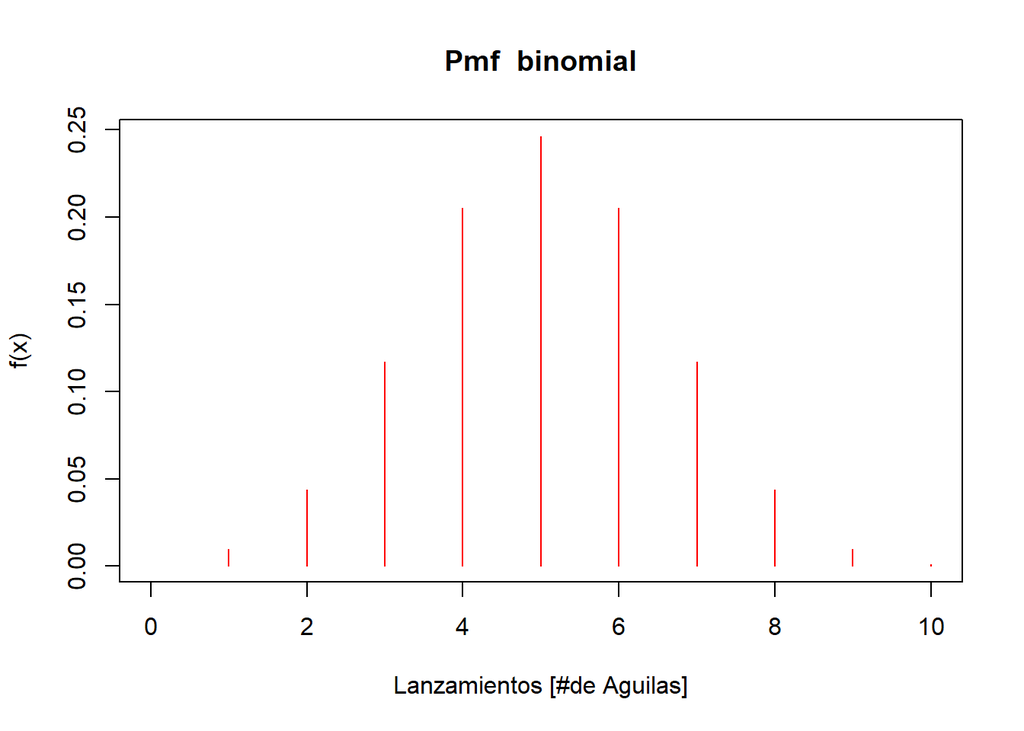

```r
a<-rep(0,10)
for (i in seq(0,10,1)){
  a[i]<-dbinom(i, 10,.5)
}

plot(a, type="h", xlab="Lanzamientos [#de Aguilas]", ylab="f(x)", main = "Pmf  binomial", xlim = c(0,10), col="red")
```

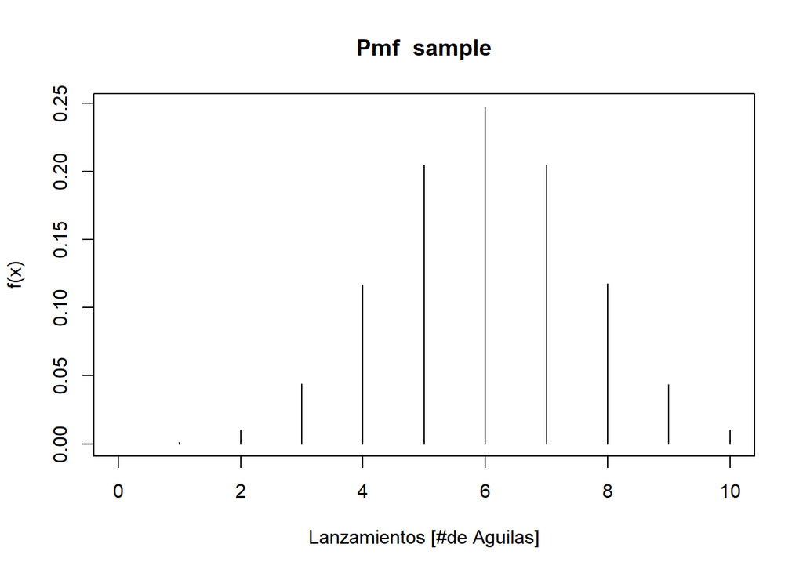

```r
plot(c[1:10], type="h", xlab="Lanzamientos [#de Aguilas]", ylab="f(x)" , main= "Pmf  sample", xlim = c(0,10))
```

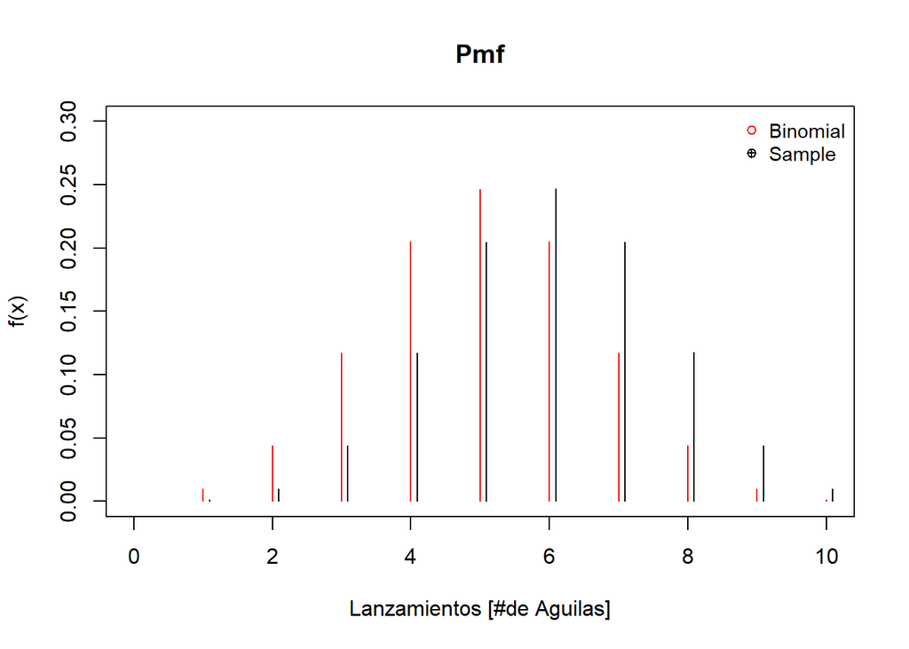

```r
#comparando las PMF
plot(a, type="h", xlab="Lanzamientos [#de Aguilas]", ylab="f(x)" , main= "Pmf", xlim = c(0,10), ylim=c(0,.3), col="red")
lines(1:10+.09,c[1:10], type="h", ylim=c(0,.25))
legend("topright", legend=c("Binomial", "Sample"), pch=c(1,10),
       col=c("red", "black"),
       horiz=FALSE, bty='n', cex=0.9)
```

3. Repita los dos incisos anteriores para una moneda desequilibrada que tiene probabilidad p = 0:3 de obtener un aguila cuando se lanza. Que observa?

```r
rm(list=ls())
count2<-rep(0,1000000)
pb<-txtProgressBar(1, 1000000,1)
for (i in seq(1,1000000,1)){
  LanzamientoMoneda2<-sample(0:1,10,.3)
  count2[i]<-(length(which(LanzamientoMoneda2==1)))
  setTxtProgressBar(pb,i)
}
count2[1:3]
```

```
## [1] 4 6 4
```

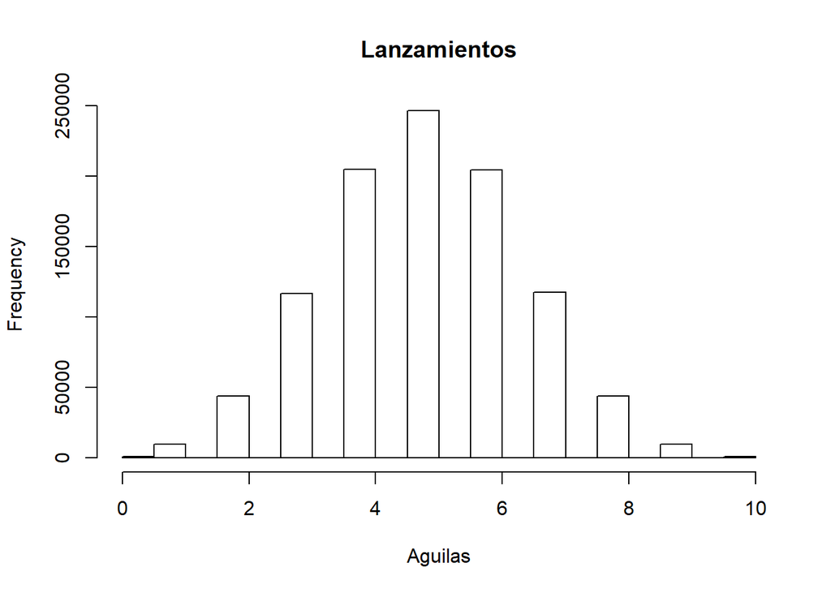

```r
hist(count2, xlab="Aguilas", main="Lanzamientos")
```

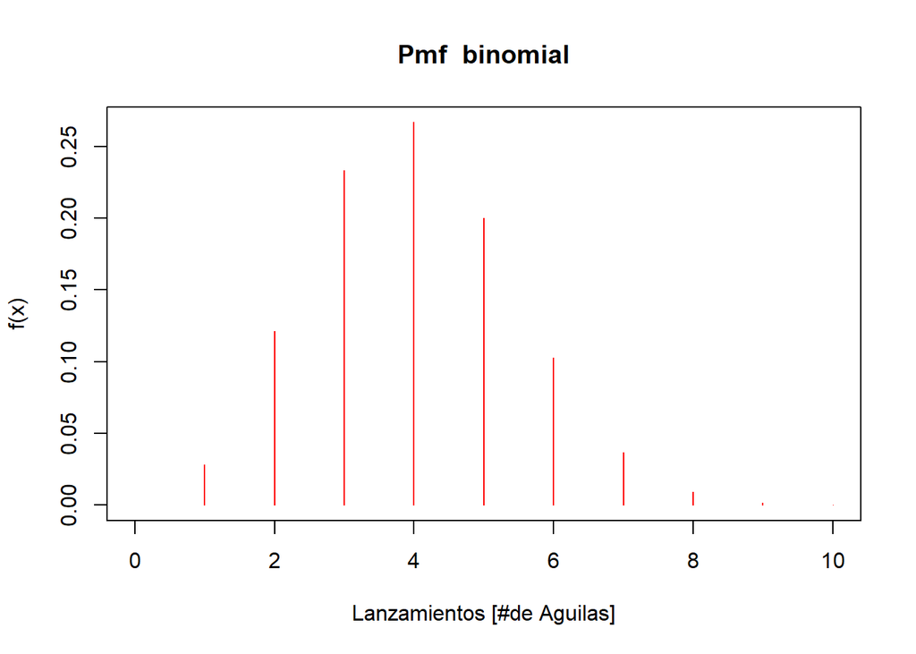

```r
b<-table(count2)
c<-rep(0,11)
for (i in seq(1,length(b),1)){
  c[i]<-b[[i]]/1000000
}

a<-rep(0,10)

a<-dbinom(0:10, 10,.3)


plot(a, type="h", xlab="Lanzamientos [#de Aguilas]", ylab="f(x)", main = "Pmf  binomial", xlim = c(0,10), col="red")
```

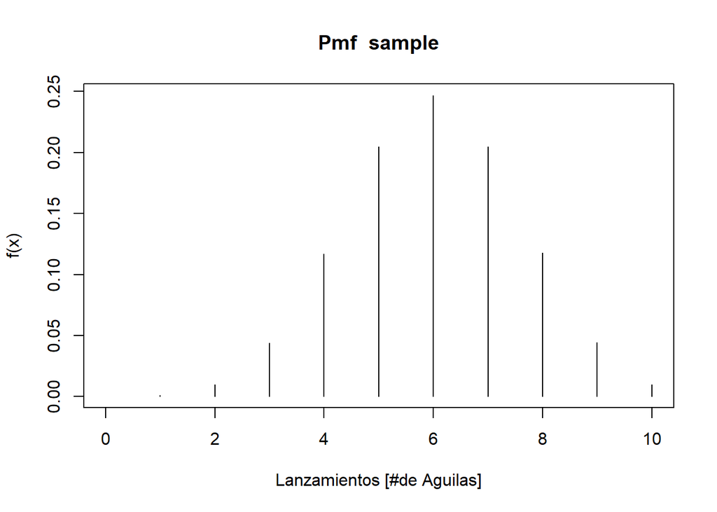

```r
plot(c, type="h", xlab="Lanzamientos [#de Aguilas]", ylab="f(x)" , main= "Pmf  sample", xlim = c(0,10))
```

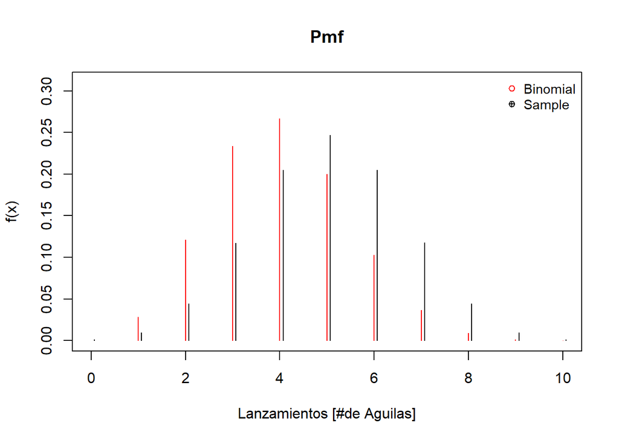

```r
plot(a, type="h", xlab="Lanzamientos [#de Aguilas]", ylab="f(x)" , main= "Pmf", xlim = c(0,10), ylim=c(0,.31), col="red")
lines(0:10+.07, c, type="h", xlim = c(1,10), ylim=c(0,.31))
legend("topright", legend=c("Binomial", "Sample"), pch=c(1,10),
       col=c("red", "black"),
       horiz=FALSE, bty='n', cex=0.9)
```